# Confusion Metrics

Glenn Slade

02/12/2022

## Struizendam 2 Survey Area

## Random Forest Classification - Accuracy Assessment

## 5 Bands

This script explores in more detail the accuracy assessment results derived from the random forest classification carried out with the SKlearn machine learning package in Python. This script uses the diffeR package in R and explores the alternatives to using kappa for confusion matrix accuracy assessment and calculates confusion matrix metrics as per Pontius Jr., R.G., Millones, M. 2011. Death to Kappa: birth of quantity disagreement and allocation disagreement for accuracy assessment. International Journal of Remote Sensing 32 (15), 4407-4429. Information about precision, recall, f1_score calculations can be found at http://scikit-learn.org/stable/modules/generated/sklearn.metrics.precision_recall_fscore_support.html

```r
Confusion1 <- read.csv("E:/Glenn/Botswana/RF/Python/Struizendam_2/Struizendam_2_RF_conf_matrix.csv")
Base_results <- read.csv("E:/Glenn/Botswana/RF/Python/Struizendam_2/Struizendam_2_RF_Summary.txt", header = FALSE)
Importance <- read.csv("E:/Glenn/Botswana/RF/Python/Struizendam_2/Struizendam_2_RF_Importance.txt")

# Prepare data table for diffeR package

Confusion4 <- subset(Confusion1, select = -c(row_0,All) )#removes unwanted columns from original Python output
Confusion3 <- Confusion4[-c(6),]#removes the last totals row
Confusion2 <- as.matrix(Confusion3) #converts table into matrix
```

The landcover type codes are as follows 1= Prosopis 2= Bare Ground 3= Dry Grass, leaf litter 4= Gnidia 5= Camel Thorn 6= Rhigosom Trichotomom

```r
print (Base_results)
```

```
##                                                      V1
## 1               precision    recall  f1-score   support
## 2            1       0.91      0.86      0.88      1124
## 3            2       1.00      1.00      1.00      1116
## 4            3       1.00      1.00      1.00      1114
## 5            4       0.80      0.89      0.84       748
## 6            5       1.00      0.99      1.00      1369
## 7     accuracy                           0.95      5471
## 8    macro avg       0.94      0.95      0.94      5471
## 9 weighted avg       0.95      0.95      0.95      5471
```

```r
print (Confusion1)
```

```
##   row_0   X1   X2   X3  X5   X6  All
## 1     1  962    0    0 162    0 1124
## 2     2    0 1116    0   0    0 1116
## 3     3    0    0 1109   0    5 1114
## 4     5   85    0    0 663    0  748
## 5     6    6    0    0   2 1361 1369
## 6   All 1053 1116 1109 827 1366 5471
```

```r
print (Confusion4)
```

```
##     X1   X2   X3  X5   X6
## 1  962    0    0 162    0
## 2    0 1116    0   0    0
## 3    0    0 1109   0    5
## 4   85    0    0 663    0
## 5    6    0    0   2 1361
## 6 1053 1116 1109 827 1366
```

```r
print(Confusion3)
```

```
##    X1   X2   X3  X5   X6
## 1 962    0    0 162    0
## 2   0 1116    0   0    0
## 3   0    0 1109   0    5
## 4  85    0    0 663    0
## 5   6    0    0   2 1361
```

```r
print (Confusion2)
```

```
##    X1   X2   X3  X5   X6
## 1 962    0    0 162    0
## 2   0 1116    0   0    0
## 3   0    0 1109   0    5
## 4  85    0    0 663    0
## 5   6    0    0   2 1361
```

The Band Selection Importance Scores for the Random Forest Classification are

```r
print (Importance)
```

```
##   Band.1.importance..0.14675917080617512
## 1 Band 2 importance: 0.14985916269142457
## 2   Band 3 importance: 0.258904152597259
## 3 Band 4 importance: 0.27239570652069733
## 4 Band 5 importance: 0.17208180738444392
```

Band 1 = Blue Band 2 = Green Band 3 = Red Band 4 = Red_Edge Band 5 = NIR Band 6 = CHM (Canopy Height Model)

We can now calculate quantity, exchange and shift components of difference, as well as the overall difference, at the category level from a contingency table derived from the crosstabulation between a comparison variables and a reference variable. The basics difference assessment is as follows:

```r
diffTablej(Confusion2, digits = 2, analysis = "error")
```

```
##   Category Omission Agreement Comission Quantity Exchange Shift
## 1       X1       91       962       162       71      170    12
## 2       X2        0      1116         0        0        0     0
## 3       X3        0      1109         5        5        0     0
## 4       X5      164       663        85       79      170     0
## 5       X6        5      1361         8        3        0    10
## 6  Overall      260      5211       260       79      170    11
```

We can then calculate a stacked barplot showing for each category the quantity, exchange and shift components of difference between the comparison map/variable and the reference map/variable.

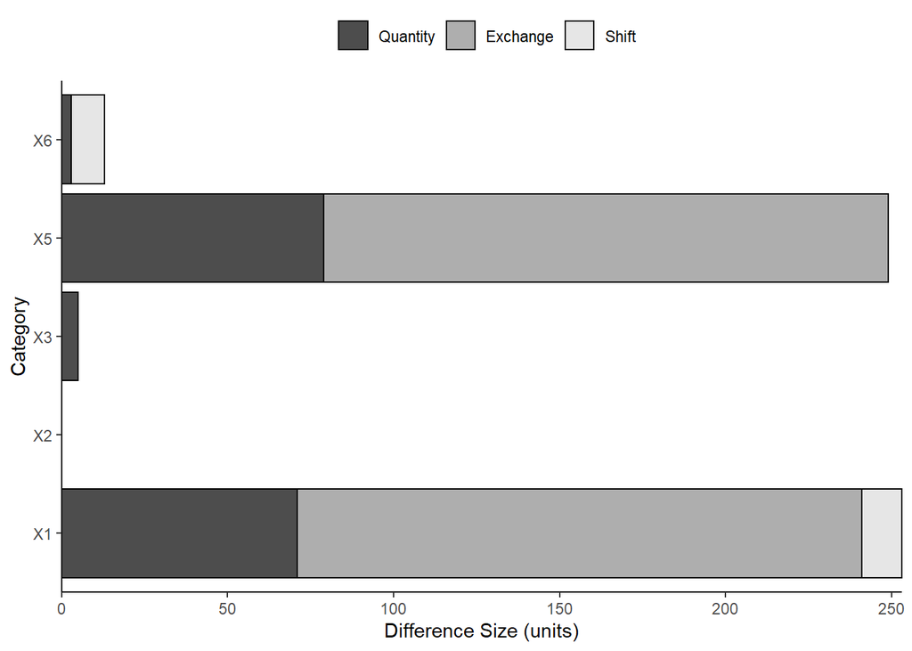

```r
categoryComponentsPlot (ctmatrix=Confusion2)
```

We can then calculate exchange and overall difference metrics

```r
exchangeDij(Confusion2)
```

```
##    X1 X2 X3 X5 X6
## 1   0  0  0  0  0
## 2   0  0  0  0  0
## 3   0  0  0  0  0
## 4 170  0  0  0  0
## 5   0  0  0  0  0
```

```r
exchangeDj(Confusion2)
```

```
##   1   2   3   4   5
## 170   0   0 170   0
```

```r
overallAllocD(Confusion2)
```

```
## [1] 181
```

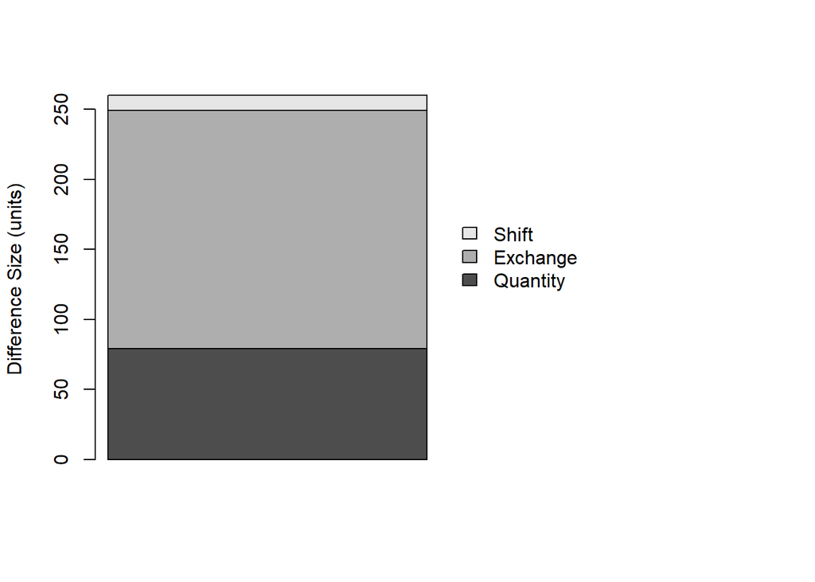

```r
overallComponentsPlot(ctmatrix=Confusion2)
```

```r
overallDiff(Confusion2)
```

```
## [1] 260
```

```r
overallDiffCatj(Confusion2)
```

```
##   1   2   3   4   5
## 253   0   5 249  13
```

```r
overallExchangeD(Confusion2)
```

```
## [1] 170
```

```r
overallQtyD(Confusion2)
```

```
## [1] 79
```

```r
overallShiftD(Confusion2)
```

```
## [1] 11
```

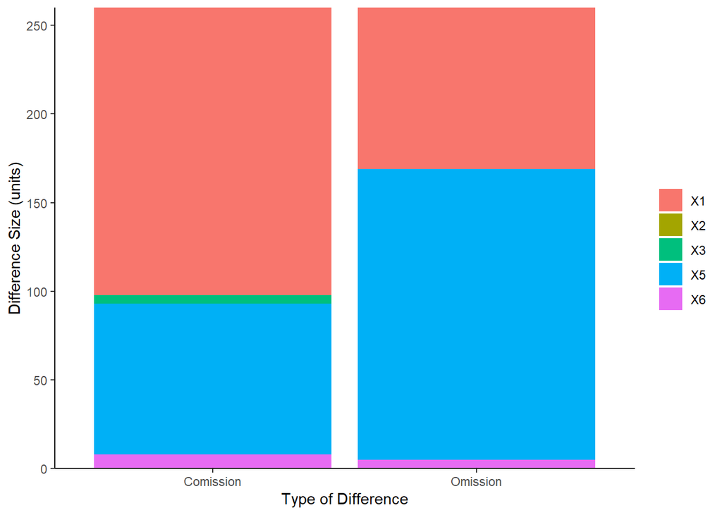

```r
overallSourcesPlot(ctmatrix=Confusion2)
```

```r
quantityDj(Confusion2)
```

```
##  1  2  3  4  5
## 71  0  5 79  3
```

We can then calculate shift difference at the category level from a contingency table derived from the crosstabulation between comparison variable and reference variable. Shift refers to the difference remaining after subtracting quantity difference and exchange from the overall difference

```r
shiftDj(Confusion2)
```

```
##  1  2  3  4  5
## 12  0  0  0 10
```

And then produce a stacked bar plot showing the ommission and commission components for each category

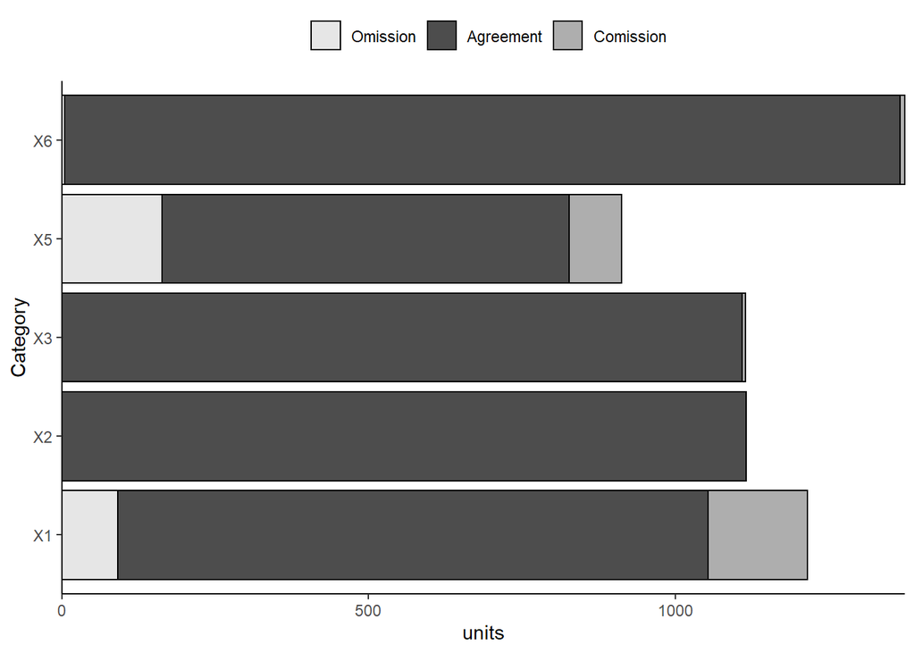

```r
categorySourcesPlot(ctmatrix=Confusion2)
```